# DSC531 Semester Project - Amazon Data Science Books

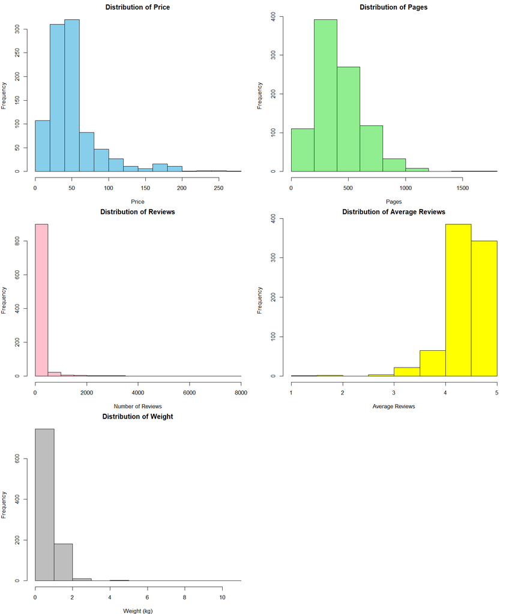

**hypothesis_1_price_pages.png**

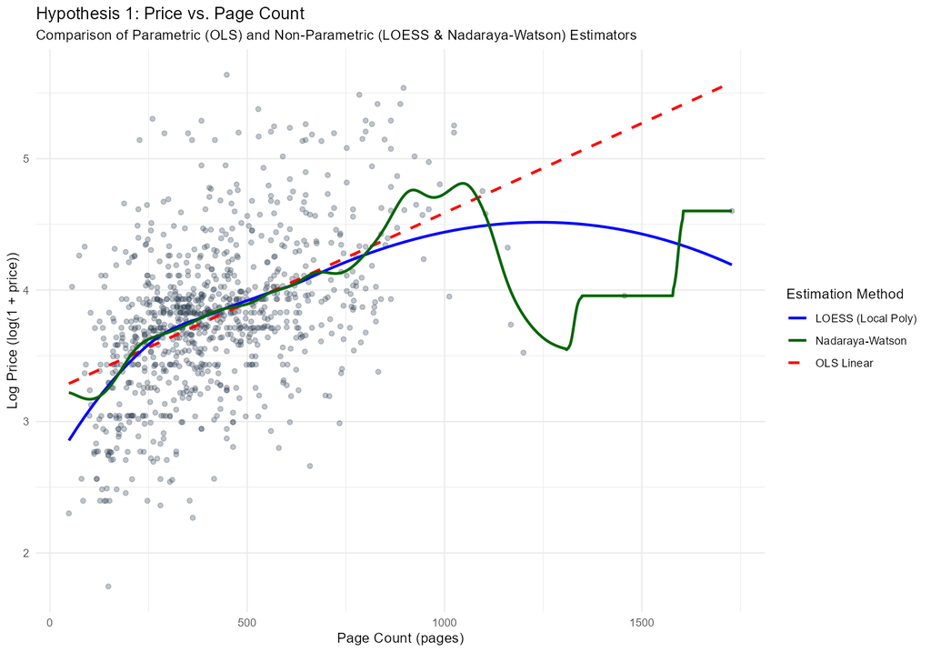

**hypothesis_2_price_reviews.png**

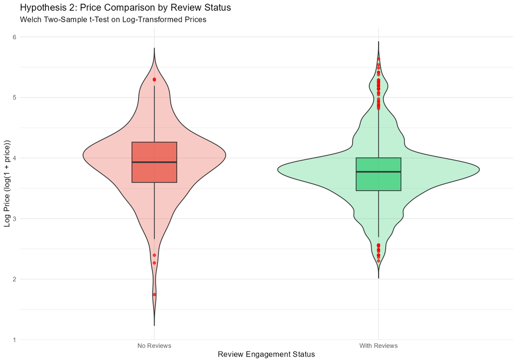

**hypothesis_3_ratings_engagement.png**

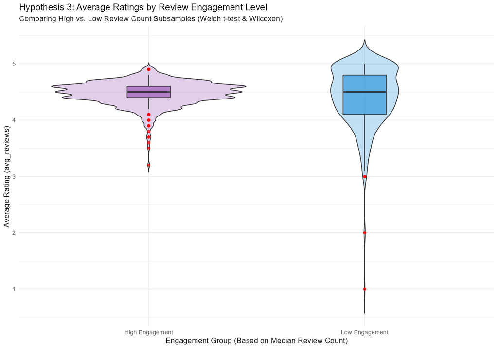

**hypothesis_4_reviews_price.png**

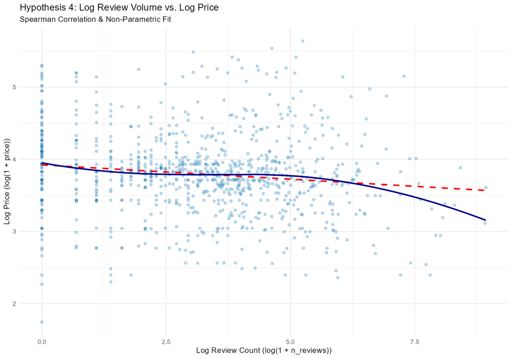

**hypothesis_5_rating_price.png**

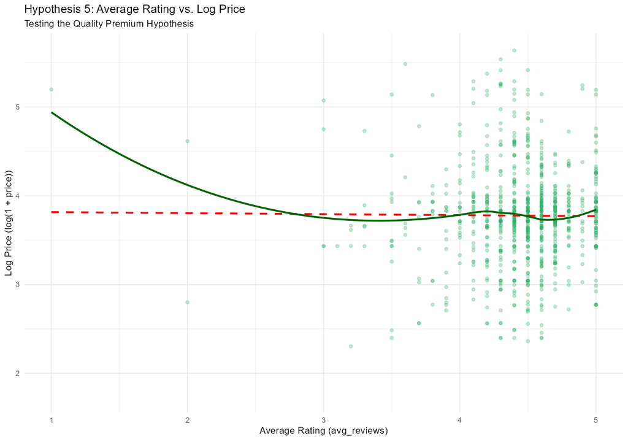

**key_numeric_variables_histograms_density.png**

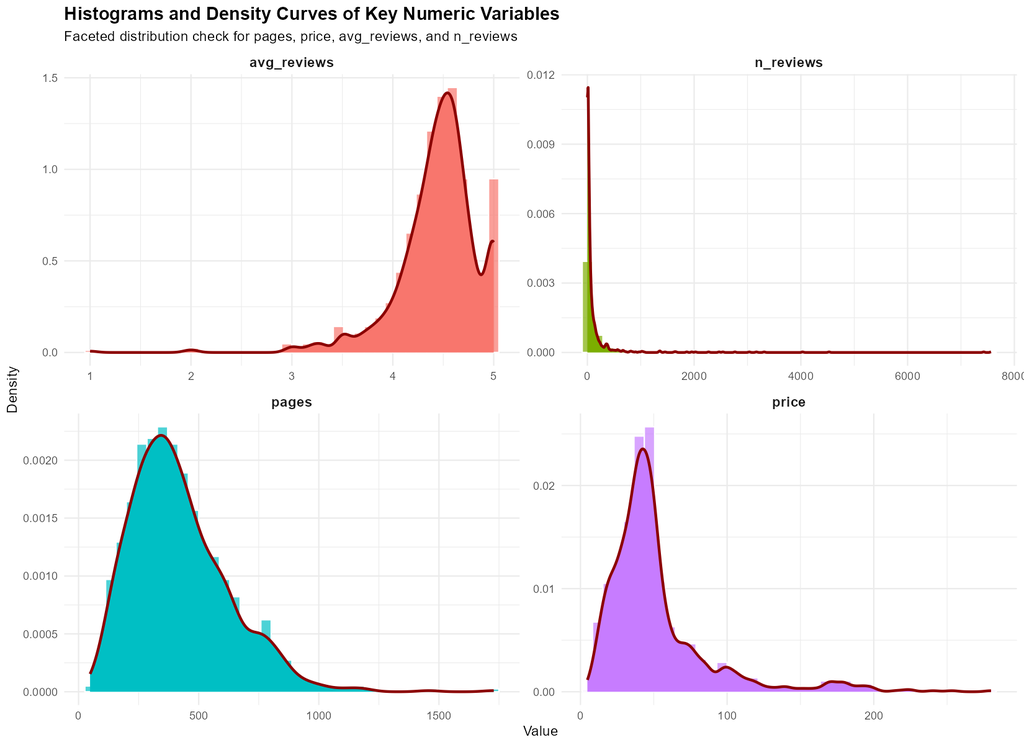

**ols_model_diagnostics.png**

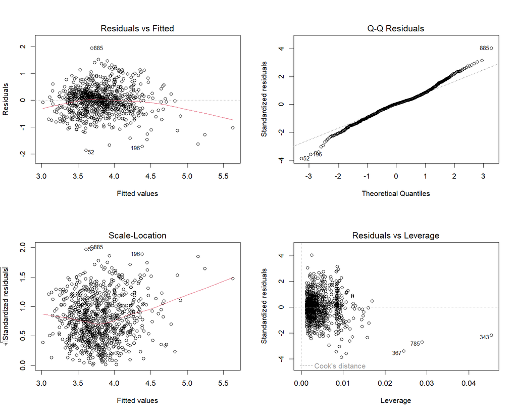

**pairwise_scatterplot_matrix.png**

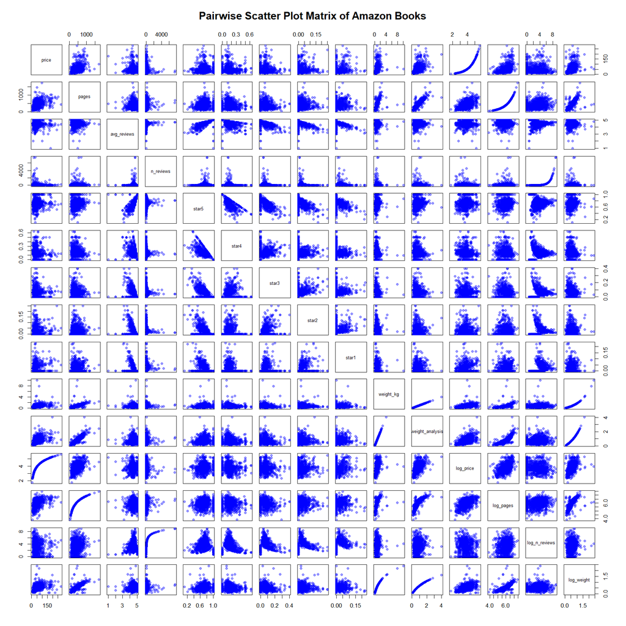

**price_vs_log_price_histograms.png**

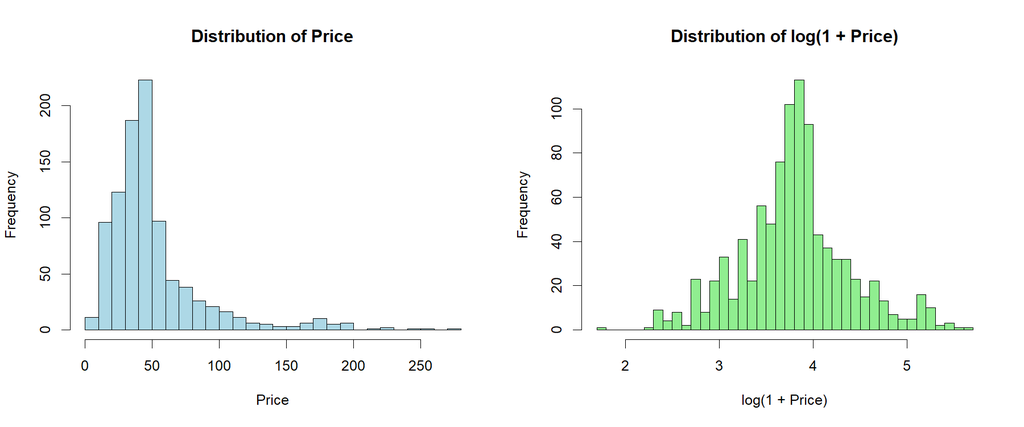

**scatterplots_log_transformed.png**

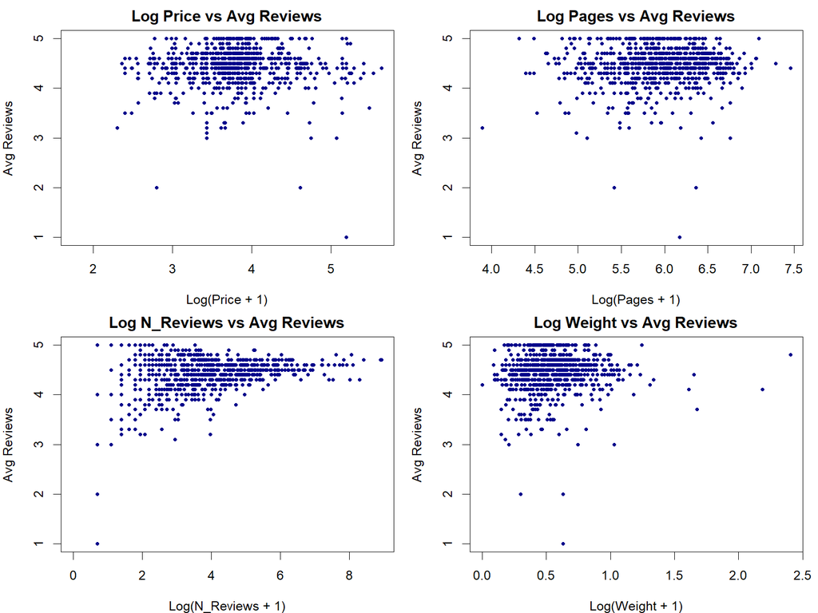

**scatterplots_original.png**

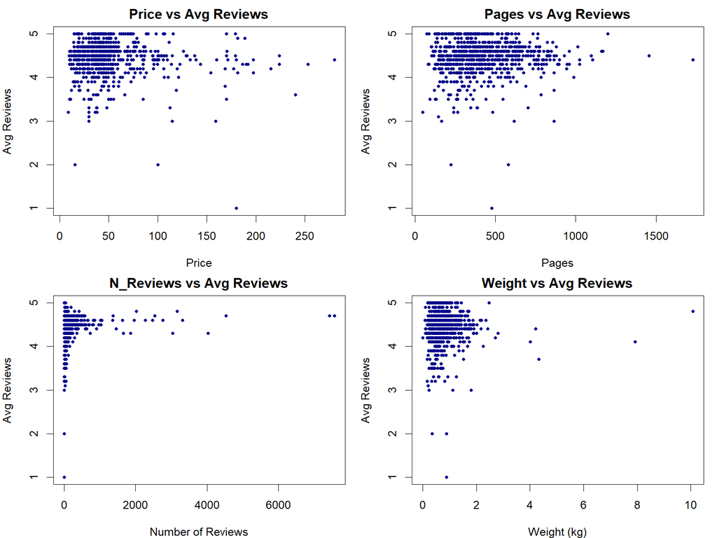

**star_variables_boxplots.png**

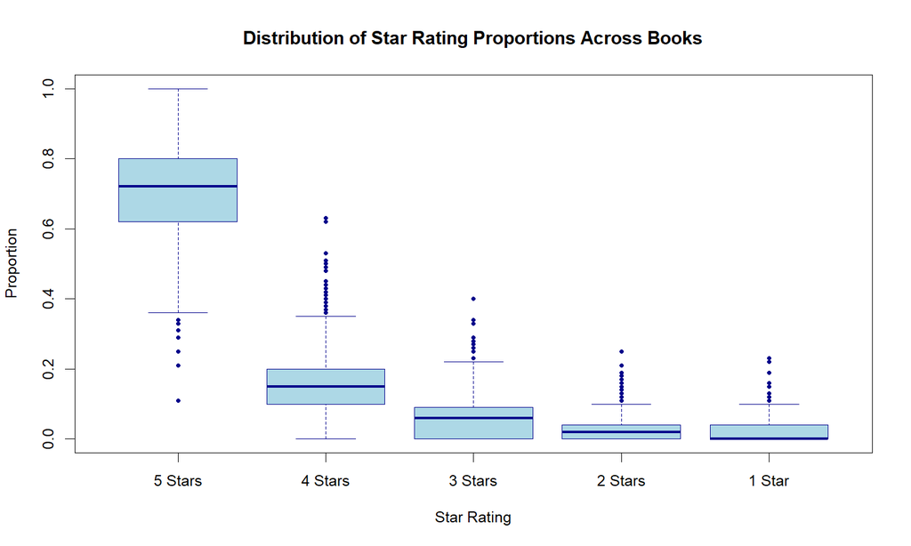

**star_variables_histograms_density.png**

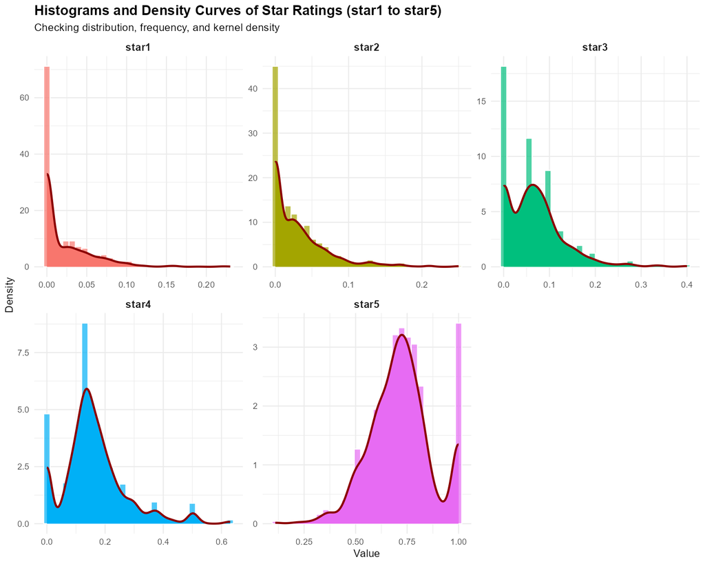

**vif_diagnostics_chart.png**

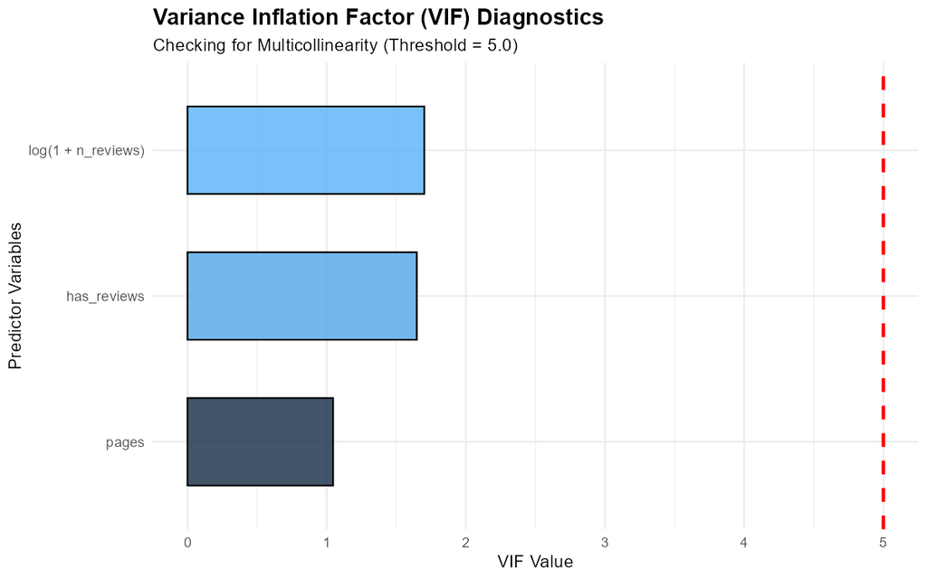